## Dataset

The dataset evaluates the obesity risk based on factors such as gender, age, number of meals, consumption of alcohol, physical activity frequency, etc. It includes 20758 observations and 18 columns

```r
library(tidyverse)
my_data <- read.csv("obesity_level.csv")
summary(my_data)
```

```
##        id              Gender           Age            Height
##  Min.   :    0   Length   :20758   Min.   :14.00   Min.   :1.450
##  1st Qu.: 5189   N.unique :    2   1st Qu.:20.00   1st Qu.:1.632
##  Median :10378   N.blank  :    0   Median :22.82   Median :1.700
##  Mean   :10378   Min.nchar:    4   Mean   :23.84   Mean   :1.700
##  3rd Qu.:15568   Max.nchar:    6   3rd Qu.:26.00   3rd Qu.:1.763
##  Max.   :20757                     Max.   :61.00   Max.   :1.976
##      Weight       family_history_with_overweight      FAVC
##  Min.   : 39.00   Min.   :0.0000                 Min.   :0.0000
##  1st Qu.: 66.00   1st Qu.:1.0000                 1st Qu.:1.0000
##  Median : 84.06   Median :1.0000                 Median :1.0000
##  Mean   : 87.89   Mean   :0.8196                 Mean   :0.9144
##  3rd Qu.:111.60   3rd Qu.:1.0000                 3rd Qu.:1.0000
##  Max.   :165.06   Max.   :1.0000                 Max.   :1.0000
##       FCVC            NCP               CAEC           SMOKE
##  Min.   :1.000   Min.   :1.000   Length   :20758   Min.   :0.0000
##  1st Qu.:2.000   1st Qu.:3.000   N.unique :    4   1st Qu.:0.0000
##  Median :2.394   Median :3.000   N.blank  :    0   Median :0.0000
##  Mean   :2.446   Mean   :2.761   Min.nchar:    1   Mean   :0.0118
##  3rd Qu.:3.000   3rd Qu.:3.000   Max.nchar:   10   3rd Qu.:0.0000
##  Max.   :3.000   Max.   :4.000                     Max.   :1.0000
##       CH2O            SCC              FAF                TUE
##  Min.   :1.000   Min.   :0.0000   Min.   :0.000000   Min.   :0.0000
##  1st Qu.:1.792   1st Qu.:0.0000   1st Qu.:0.008013   1st Qu.:0.0000
##  Median :2.000   Median :0.0000   Median :1.000000   Median :0.5739
##  Mean   :2.029   Mean   :0.0331   Mean   :0.981747   Mean   :0.6168
##  3rd Qu.:2.550   3rd Qu.:0.0000   3rd Qu.:1.587406   3rd Qu.:1.0000
##  Max.   :3.000   Max.   :1.0000   Max.   :3.000000   Max.   :2.0000
##         CALC             MTRANS           X0be1dad
##  Length   :20758   Length   :20758   Length   :20758
##  N.unique :    3   N.unique :    5   N.unique :    7
##  N.blank  :    0   N.blank  :    0   N.blank  :    0
##  Min.nchar:    1   Min.nchar:    4   Min.nchar:   12
##  Max.nchar:   10   Max.nchar:   21   Max.nchar:   19
##
```

### Histogram plot

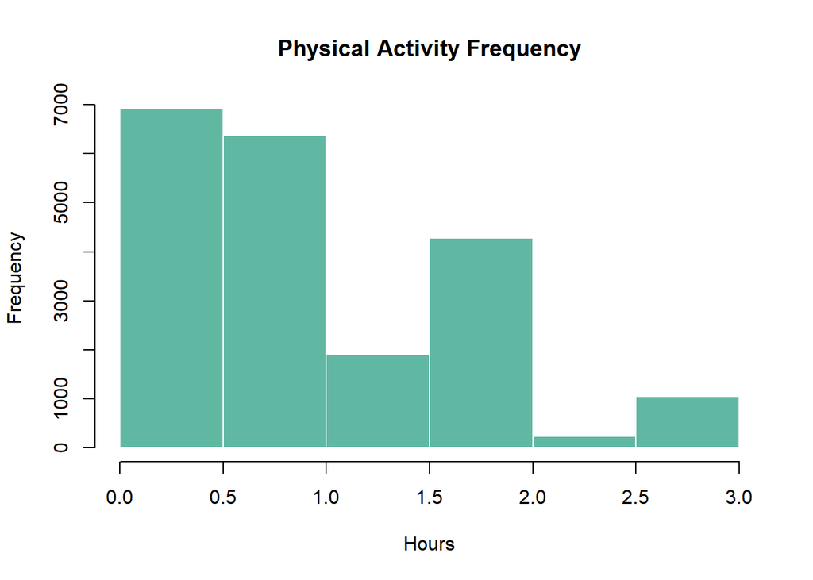

```r
hist(my_data$FAF, breaks = 5, xlab="Hours",
     main = "Physical Activity Frequency",
     col = "#60B8A3",
     border = "white")
```

The histogram shows the distribution of time (hours) spent on physical activity of participants. The right-skewed distribution indicates that the majority of individuals spend between **0.0 and 1.0 hours** for physical activity.

Interestingly, the distribution shows a *secondary peak* at **1.5 to 2.0 hours**, representing a significant proportion of participants with physical activity duration.

We assume that this peak comes from the young people - those in their prime - who are ready to devote more time to physical activity.

Let’s see

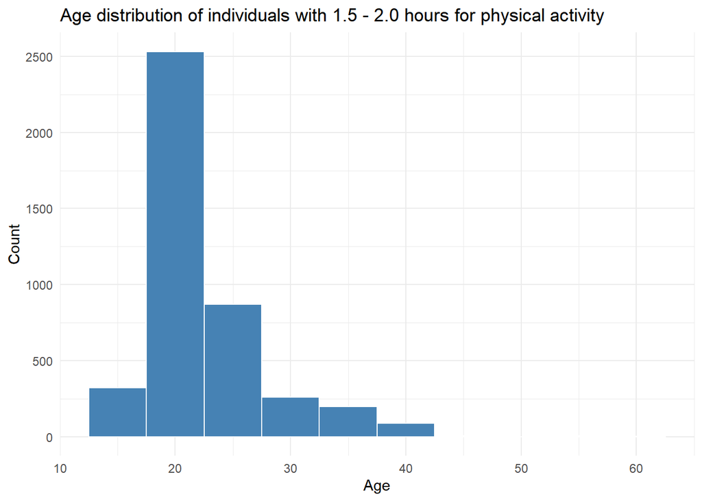

```r
group_15_20 <- my_data %>%
  filter(FAF >= 1.5, FAF <= 2.0)

ggplot(group_15_20, aes(x = Age)) +
         geom_histogram(binwidth=5, fill ='steelblue', color='white')+
         labs(title = "Age distribution of individuals with 1.5 - 2.0 hours for physical activity",
              x = "Age",
              y = "Count") +
         theme_minimal()
```

From the graph, we easily see that most of the participants whose age is *around 20* devote **1.5 to 2.0 hours** to physical activity.

### Statistical Calculation

**Mean of Physical Activity Frequency**

```r
mean_activity <- mean(my_data$FAF, na.rm = TRUE)
mean_activity
```

```
## [1] 0.9817466
```

**Standard deviation of Physical Activity Frequency**

```r
sd_activity <- sd(my_data$FAF, na.rm = TRUE)
sd_activity
```

```
## [1] 0.838302
```

### Apply correlation

**to detect a relationship between Age and Physical Activity Frequency**

```r
cor.test(my_data$Age, my_data$FAF)
```

```
##
##  Pearson's product-moment correlation
##
## data:  my_data$Age and my_data$FAF
## t = -28.225, df = 20756, p-value < 2.2e-16
## alternative hypothesis: true correlation is not equal to 0
## 95 percent confidence interval:
##  -0.2053258 -0.1791238
## sample estimates:
##        cor
## -0.1922591
```

**R-squared and p-value**

```r
linear_age_faf <- lm(FAF ~ Age, data = my_data)
summary(linear_age_faf)
```

```
##
## Call:
## lm(formula = FAF ~ Age, data = my_data)
##
## Residuals:
##      Min       1Q   Median       3Q      Max
## -1.26061 -0.83368 -0.06227  0.60070  2.90112
##
## Coefficients:
##              Estimate Std. Error t value Pr(>|t|)
## (Intercept)  1.657303   0.024606   67.35   <2e-16 ***
## Age         -0.028335   0.001004  -28.23   <2e-16 ***
## ---
## Signif. codes:  0 '***' 0.001 '**' 0.01 '*' 0.05 '.' 0.1 ' ' 1
##
## Residual standard error: 0.8227 on 20756 degrees of freedom
## Multiple R-squared:  0.03696,    Adjusted R-squared:  0.03692
## F-statistic: 796.7 on 1 and 20756 DF,  p-value: < 2.2e-16
```

**Scatter plot**

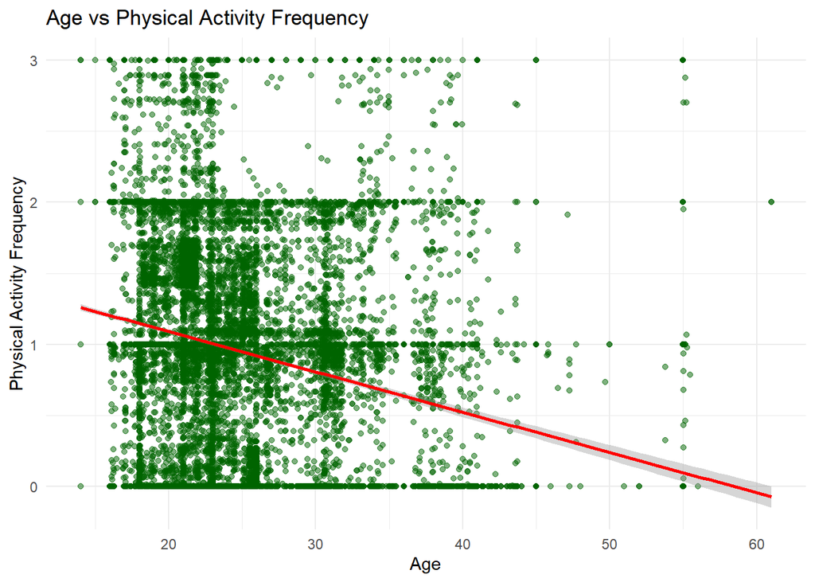

```r
ggplot(my_data, aes(x = Age, y = FAF)) +
  geom_point(alpha = 0.5, color = "darkgreen") +
  geom_smooth(method="lm", color='red') +
  theme_minimal() +
  labs(title = "Age vs Physical Activity Frequency",
       x = "Age",
       y = "Physical Activity Frequency")
```

The correlation coefficient is **-0.19**, indicating that a weak relationship. In the other hand, when age increases, the Physical Activity Frequency tends to decrease slightly.

The **p-value < 2.2e-16**, showing that the relation is statistically significant. The linear regression model produced **R-squared = 0.03696**, meaning Age explains only **3.7%** of the variation in Physical Activity Frequency. Therefore, although Age has a statistically significant impact on physical activity, it is not a strong predictor, and other factors might play a much larger role.

### Second statistic test

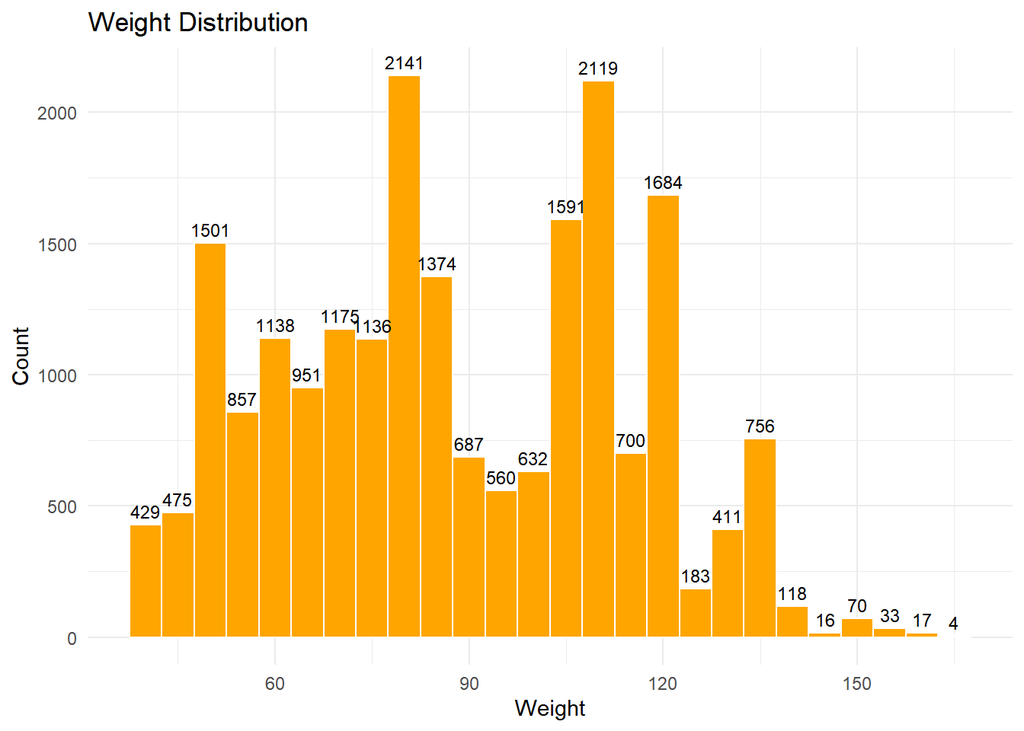

```r
ggplot(my_data, aes(x = Weight)) +
  geom_histogram(binwidth = 5, fill = "orange", color = "white") +
  geom_text(stat = "bin",
            binwidth = 5,
            aes(label = ..count..),
            vjust = -0.5,
            color = "black",
            size = 3) +
  labs(title = "Weight Distribution", x = "Weight", y = "Count") +
  theme_minimal()
```

The Weight distribution is **not normal** It spreads widely across the range of weights. It shows clear peaks around: 50, 80, 110, and 120. This indicates that weight in the dataset is not centered around a single value but forms multiple clusters

### T-test

I divided my dataset into two groups based on the variable Gender (Male vs Female) and used t-test to test for significant differences between the two groups.

```r
t.test(Weight ~ Gender, data = my_data)
```

```
##
##  Welch Two Sample t-test
##
## data:  Weight by Gender
## t = -17.231, df = 19187, p-value < 2.2e-16
## alternative hypothesis: true difference in means between group Female and group Male is not equal to 0
## 95 percent confidence interval:
##  -6.969635 -5.545940
## sample estimates:
## mean in group Female   mean in group Male
##             84.77184             91.02963
```

The t‑test: The mean Weight for males is **91.03**, while the mean Weight of females is **84.77** the **p-value < 0.05**, indicating that the difference is statistically significant.